# Acral_Melanoma

Chen Lu

2/16/2021

```r
setwd('/Users/chenyuelu/Desktop/things/MBI/research/SemenovLab/Melanoma_Pearl/')
read_excel_allsheets <- function(filename, tibble = TRUE) {
    # I prefer straight data.frames
    # but if you like tidyverse tibbles (the default with read_excel)
    # then just pass tibble = TRUE
    sheets <- readxl::excel_sheets(filename)
    x <- lapply(sheets, function(X) readxl::read_excel(filename, sheet = X))
    if(!tibble) x <- lapply(x, as.data.frame)
    names(x) <- sheets
    x
}
df_all <- read_excel_allsheets('Melanoma AGO 2021_20_02_notes.xlsx')
```

[output not shown]

```r
df <- df_all$`Use this Sheet!`
head(df)
```

| ID | Gender | Insurance | Self-pay-0, Medicaid-1, Other-2, International-3 | Zip | Race/Ethnicity | Marital Status | DOB | vital status (1 = alive, 0 = dead) | Age of last f/u or death | Age at diagnosis | Location | Laterality | Date of diagnosis | Final Stage | immunotherapy | chemotherapy? | Column1 | Column2 |
| --- | --- | --- | --- | --- | --- | --- | --- | --- | --- | --- | --- | --- | --- | --- | --- | --- | --- | --- |
| 103308001 | Female | ANTHEM BC OF MAINE HMO, XVH0000A01621, 2B, BC OUT OF STATE HMO:PO BOX 9197:QUINCY, MA 021719197 | 2 | 04856 | White | Single | 1992-07-13 | 1 | 2010-08-10 | 12.213552361396303 | foot | R | 38259 | 3 | N | N | NA | NA |
| 106124502 | Female | INTERNATIONAL COMMERCIAL, 4045-1-0039, 140001, | 3 | @ | Black or African American | Married | 1962-10-17 | 1 | 2019-11-12 | 47.915126625598901 | foot | R | 40437 | 1 | N | N | NA | NA |
| 111350037 | Female | CIGNA, U6729035002, 1006, | 2 | 03053 | White | Married | 1960-02-24 | 1 | 2020-12-28 | 56.484599589322379 | foot | R | 42601 | 3 | Y | Y | NA | NA |
| 106590286 | Female | TUFTS MCR PREF HMO OUTPCP, S0035355401, GH, PO BOX 9183:WATERTOWN, MA 024719183 | 2 | 02130 | White | Unknown | 1934-07-25 | 0 | 2013-01-06 | 73.938398357289529 | hand | L | 39631 | 2 | N | N | NA | NA |
| 103219250 | Female | CIGNA, U3568278202, 1006, | 2 | 32081 | White | Married | 1963-05-04 | 1 | 2019-12-03 | 50.475017111567418 | foot | L | 41571 | 0 | N | N | NA | NA |
| 109334933 | Male | MEDICARE, 3E30D69FN22, 2001, | 2 | 02543 | Not Recorded | Married | 1946-10-01 | 1 | 2020-12-30 | 31.252566735112936 | hand | L | 28491 | na | N | N | NA | NA |

```r
df_clean <- df %>%
    mutate(race_ethnicity = case_when(`Race/Ethnicity` == 'White' ~ 'Non-Hispanic White',
           `Race/Ethnicity` == 'Black or African American' ~ 'Non-Hispanic Black',
            `Race/Ethnicity` == 'Not Recorded' ~ 'Unknown',
            `Race/Ethnicity` == 'Hispanic-Other' ~ 'Hispanic',
            `Race/Ethnicity` == 'Asian' ~ 'Asian',
            `Race/Ethnicity` == 'American Indian' ~ 'Other',
            `Race/Ethnicity` == 'Native Hawaiian or Pacific Islander' ~ 'Other',
            `Race/Ethnicity` == 'Hispanic-Black' ~ 'Hispanic')) %>%
    mutate(white = case_when(`Race/Ethnicity` == 'White' ~ 'Non-Hispanic White',
                             `Race/Ethnicity` == 'Not Recorded' ~ 'Unknown',
                             TRUE ~ 'POC')) %>%
    mutate(insurance_type = case_when(`Self-pay-0, Medicaid-1, Other-2, International-3` == 0 ~ 'Self-pay',
                                      `Self-pay-0, Medicaid-1, Other-2, International-3` == 1 ~ 'Medicaid',
                                      `Self-pay-0, Medicaid-1, Other-2, International-3` == 2 ~ 'Private_or_public',
                                      `Self-pay-0, Medicaid-1, Other-2, International-3` == 3 ~ 'International')) %>%
    mutate(dx_date = as.Date(as.numeric(`Date of diagnosis`), origin = '1899-12-30')) %>% # some formatting necessary for R to read dates
    select(ID, Gender, race_ethnicity, white, `Marital Status`, insurance_type, DOB, dx_date, `Final Stage`, Location, Laterality, `Age  of last f/u or death`, `vital status (1 = alive, 0 = dead)`, immunotherapy, `chemotherapy?`)
colnames(df_clean) <- c('ID', 'Gender', 'Race_ethnicity','White_or_POC', 'Marital_Status', 'insurance_type', 'DOB', 'dx_date', 'Final_Stage', 'Location', 'Laterality', 'follow_up_date', 'Alive', 'immuno','chemo')

# define reference group for each variable
df_clean$Race_ethnicity <- factor(df_clean$Race_ethnicity, levels=c("Non-Hispanic White","Non-Hispanic Black","Hispanic","Asian","Other","Unknown"))
df_clean$Race_ethnicity = relevel(df_clean$Race_ethnicity, ref = "Non-Hispanic White")

df_clean$White_or_POC <- factor(df_clean$White_or_POC, levels=c("Non-Hispanic White","POC","Unknown"))
df_clean$White_or_POC = relevel(df_clean$White_or_POC, ref = "Non-Hispanic White")

df_clean$Gender <- factor(df_clean$Gender, levels=c("Male", "Female"))
df_clean$Gender = relevel(df_clean$Gender, ref = "Male")

df_clean$Final_Stage <- factor(df_clean$Final_Stage, levels=c("0","1",'2','3','4','na'))
df_clean$Final_Stage = relevel(df_clean$Final_Stage, ref = "0")

df_clean$insurance_type <- factor(df_clean$insurance_type, levels=c("Private_or_public","Self-pay",'Medicaid','International'))
df_clean$insurance_type = relevel(df_clean$insurance_type, ref = "Private_or_public")

df_clean$immuno <- factor(df_clean$immuno, levels=c("Y","N"))
df_clean$immuno = relevel(df_clean$immuno, ref = "N")

df_clean$chemo <- factor(df_clean$chemo, levels=c("Y","N"))
df_clean$chemo = relevel(df_clean$chemo, ref = "N")
```

```r
race_counts <- df_clean %>%
    group_by(Race_ethnicity) %>%
    summarize(Total_Counts = n())
race_counts
```

| Race_ethnicity | Total_Counts |
| --- | --- |
| Non-Hispanic White | 341 |
| Non-Hispanic Black | 15 |
| Hispanic | 17 |
| Asian | 10 |
| Other | 3 |
| Unknown | 21 |

```r
stage_counts <- df_clean %>%
    group_by(Final_Stage) %>%
    summarize(Total_Counts = n())
stage_counts
```

| Final_Stage | Total_Counts |
| --- | --- |
| 0 | 82 |
| 1 | 104 |
| 2 | 79 |
| 3 | 94 |
| 4 | 18 |
| na | 30 |

```r
df_gender <- df_clean %>%
    group_by(Race_ethnicity,Gender) %>%
    summarise(counts=n()) %>%
    group_by(Race_ethnicity) %>%
    mutate(Total=sum(counts)) %>%
    filter(Gender=='Male') %>%
    select(Race_ethnicity, counts, Total) %>%
    rename('Males'=counts) %>%
    mutate(percentage = round(100*Males/Total,2))
# Let's see the breakdown
df_gender
```

| Race_ethnicity | Males | Total | percentage |
| --- | --- | --- | --- |
| Non-Hispanic White | 136 | 341 | 39.88 |
| Non-Hispanic Black | 6 | 15 | 40.00 |
| Hispanic | 4 | 17 | 23.53 |
| Asian | 3 | 10 | 30.00 |
| Unknown | 9 | 21 | 42.86 |

```r
# overall percentages
print(paste('total number of males:',sum(df_clean$Gender == 'Male')))
```

```
## [1] "total number of males: 158"
```

```r
print(paste('total number of people with gender labels:',length(df_clean$Gender)))
```

```
## [1] "total number of people with gender labels: 407"
```

```r
prop.test(sum(df_clean$Gender == 'Male'), length(df_clean$Gender), p = 0.5)
```

```
##
##  1-sample proportions test with continuity correction
##
## data:  sum(df_clean$Gender == "Male") out of length(df_clean$Gender), null probability 0.5
## X-squared = 19.902, df = 1, p-value = 8.153e-06
## alternative hypothesis: true p is not equal to 0.5
## 95 percent confidence interval:
##  0.3409259 0.4376314
## sample estimates:
##         p
## 0.3882064
```

```r
# separate race groups
prop.test(df_gender$Males, df_gender$Total)
```

```
##
##  5-sample test for equality of proportions without continuity
##  correction
##
## data:  df_gender$Males out of df_gender$Total
## X-squared = 2.2958, df = 4, p-value = 0.6815
## alternative hypothesis: two.sided
## sample estimates:
##    prop 1    prop 2    prop 3    prop 4    prop 5
## 0.3988270 0.4000000 0.2352941 0.3000000 0.4285714
```

```r
# White vs POC
POC_gender <- df_clean %>%
    group_by(White_or_POC,Gender) %>%
    summarise(counts=n()) %>%
    group_by(White_or_POC) %>%
    mutate(Total=sum(counts)) %>%
    filter(Gender=='Male') %>%
    select(White_or_POC, counts, Total) %>%
    rename('Males'=counts)%>%
    mutate(percentage = round(100*Males/Total,2))
POC_gender
```

| White_or_POC | Males | Total | percentage |
| --- | --- | --- | --- |
| Non-Hispanic White | 136 | 341 | 39.88 |
| POC | 13 | 45 | 28.89 |
| Unknown | 9 | 21 | 42.86 |

```r
# testing if there is a difference between white and POC in gender breakdown
prop.test(POC_gender$Males, POC_gender$Total)
```

```
##
##  3-sample test for equality of proportions without continuity
##  correction
##
## data:  POC_gender$Males out of POC_gender$Total
## X-squared = 2.175, df = 2, p-value = 0.3371
## alternative hypothesis: two.sided
## sample estimates:
##    prop 1    prop 2    prop 3
## 0.3988270 0.2888889 0.4285714
```

**Gender**

**1. Looking at overall percentage of males in the dataset, we see less than 50% were males. p-value is significant. Confidence interval does not include 0.5 (the assumption that there is equal number of males and females).**

**2. Comparing white and individual race groups. Here the null hypothesis is that the proportion of males is the same in each race group: p1 = p2 = p3 = p4 = p5. The p-value here is 0.6815, which is not significant, so we cannot reject the null hypothesis. Simply put, the gender proportions across the race groups are the same.**

**3. Comparing white and POC (combining individual race groups) and Unknown. The p-value is 0.3371, still not significant.**

```r
df_location <- df_clean %>%
    group_by(Race_ethnicity,Location) %>%
    summarise(counts=n()) %>%
    group_by(Race_ethnicity) %>%
    mutate(Total=sum(counts)) %>%
    filter(Location=='foot') %>%
    select(Race_ethnicity, counts, Total) %>%
    rename('Foot'=counts) %>%
    mutate(percentage = round(100*Foot/Total,2))
df_location
```

| Race_ethnicity | Foot | Total | percentage |
| --- | --- | --- | --- |
| Non-Hispanic White | 284 | 341 | 83.28 |
| Non-Hispanic Black | 10 | 15 | 66.67 |
| Hispanic | 17 | 17 | 100.00 |
| Asian | 9 | 10 | 90.00 |
| Other | 3 | 3 | 100.00 |
| Unknown | 14 | 21 | 66.67 |

```r
print(paste('total number of foot acral melanoma:',sum(df_clean$Location == 'foot')))
```

```
## [1] "total number of foot acral melanoma: 337"
```

```r
print(paste('total number of people with location labels:',sum(df_clean$Location!='na')))
```

```
## [1] "total number of people with location labels: 404"
```

```r
prop.test(sum(df_clean$Location == 'foot'), sum(df_clean$Location!='na'), p = 0.5)
```

```
##
##  1-sample proportions test with continuity correction
##
## data:  sum(df_clean$Location == "foot") out of sum(df_clean$Location != "na"), null probability 0.5
## X-squared = 179.11, df = 1, p-value < 2.2e-16
## alternative hypothesis: true p is not equal to 0.5
## 95 percent confidence interval:
##  0.7934447 0.8683642
## sample estimates:
##         p
## 0.8341584
```

```r
# separate race groups
prop.test(df_location$Foot, df_location$Total)
```

```
##
##  6-sample test for equality of proportions without continuity
##  correction
##
## data:  df_location$Foot out of df_location$Total
## X-squared = 11.155, df = 5, p-value = 0.0484
## alternative hypothesis: two.sided
## sample estimates:
##    prop 1    prop 2    prop 3    prop 4    prop 5    prop 6
## 0.8328446 0.6666667 1.0000000 0.9000000 1.0000000 0.6666667
```

```r
# White vs POC
POC_gender <- df_clean %>%
    group_by(White_or_POC,Location) %>%
    summarise(counts=n()) %>%
    group_by(White_or_POC) %>%
    mutate(Total=sum(counts)) %>%
    filter(Location=='foot') %>%
    select(White_or_POC, counts, Total) %>%
    rename('Foot'=counts) %>%
    mutate(percentage = round(100*Foot/Total,2))
POC_gender
```

| White_or_POC | Foot | Total | percentage |
| --- | --- | --- | --- |
| Non-Hispanic White | 284 | 341 | 83.28 |
| POC | 39 | 45 | 86.67 |
| Unknown | 14 | 21 | 66.67 |

```r
# testing if there is a difference between white and POC in gender breakdown
prop.test(POC_gender$Foot, POC_gender$Total)
```

```
##
##  3-sample test for equality of proportions without continuity
##  correction
##
## data:  POC_gender$Foot out of POC_gender$Total
## X-squared = 4.3668, df = 2, p-value = 0.1127
## alternative hypothesis: two.sided
## sample estimates:
##    prop 1    prop 2    prop 3
## 0.8328446 0.8666667 0.6666667
```

**Location**

**1. Overall there are significantly more foot acral melanoma than hand. See results above.**

**2. Comparing white and individual race groups. Here the null hypothesis is that the proportion of foot melanoma is the same in each race group: p1 = p2 = p3 = p4 = p5. The p-value here is 0.0484, which is just below the 0.05 p-value threshold, so we can maybe reject the null hypothesis. Simply put, at least one of the races had a different percentage of melanoma location from the other races.**

**3. Comparing white and POC (combining individual race groups) and Unknown. The p-value is 0.1127, not significant.**

```r
df_laterality <- df_clean %>%
    group_by(Race_ethnicity,Laterality) %>%
    summarise(counts=n()) %>%
    group_by(Race_ethnicity) %>%
    mutate(Total=sum(counts)) %>%
    filter(Laterality=='L') %>%
    select(Race_ethnicity, counts, Total) %>%
    rename('L'=counts) %>%
    mutate(percentage = round(100*L/Total,2))
df_laterality
```

| Race_ethnicity | L | Total | percentage |
| --- | --- | --- | --- |
| Non-Hispanic White | 176 | 341 | 51.61 |
| Non-Hispanic Black | 9 | 15 | 60.00 |
| Hispanic | 9 | 17 | 52.94 |
| Asian | 6 | 10 | 60.00 |
| Other | 2 | 3 | 66.67 |
| Unknown | 11 | 21 | 52.38 |

```r
print(paste('total number of left acral melanoma:',sum(df_clean$Laterality == 'L')))
```

```
## [1] "total number of left acral melanoma: 213"
```

```r
print(paste('total number of people with laterality labels:',sum(df_clean$Laterality!='na')))
```

```
## [1] "total number of people with laterality labels: 402"
```

```r
prop.test(sum(df_clean$Laterality == 'L'), sum(df_clean$Laterality!='na'), p = 0.5)
```

```
##
##  1-sample proportions test with continuity correction
##
## data:  sum(df_clean$Laterality == "L") out of sum(df_clean$Laterality != "na"), null probability 0.5
## X-squared = 1.3159, df = 1, p-value = 0.2513
## alternative hypothesis: true p is not equal to 0.5
## 95 percent confidence interval:
##  0.4797699 0.5793521
## sample estimates:
##         p
## 0.5298507
```

```r
# separate race groups
prop.test(df_laterality$L, df_laterality$Total)
```

```
##
##  6-sample test for equality of proportions without continuity
##  correction
##
## data:  df_laterality$L out of df_laterality$Total
## X-squared = 0.90962, df = 5, p-value = 0.9695
## alternative hypothesis: two.sided
## sample estimates:
##    prop 1    prop 2    prop 3    prop 4    prop 5    prop 6
## 0.5161290 0.6000000 0.5294118 0.6000000 0.6666667 0.5238095
```

```r
# White vs POC
POC_laterality <- df_clean %>%
    group_by(White_or_POC,Laterality) %>%
    summarise(counts=n()) %>%
    group_by(White_or_POC) %>%
    mutate(Total=sum(counts)) %>%
    filter(Laterality=='L') %>%
    select(White_or_POC, counts, Total) %>%
    rename('L'=counts) %>%
    mutate(percentage = round(100*L/Total,2))
POC_laterality
```

| White_or_POC | L | Total | percentage |
| --- | --- | --- | --- |
| Non-Hispanic White | 176 | 341 | 51.61 |
| POC | 26 | 45 | 57.78 |
| Unknown | 11 | 21 | 52.38 |

```r
prop.test(POC_laterality$L, POC_laterality$Total)
```

```
##
##  3-sample test for equality of proportions without continuity
##  correction
##
## data:  POC_laterality$L out of POC_laterality$Total
## X-squared = 0.60569, df = 2, p-value = 0.7387
## alternative hypothesis: two.sided
## sample estimates:
##    prop 1    prop 2    prop 3
## 0.5161290 0.5777778 0.5238095
```

**Laterality**

**Overall, there is no difference in laterality. Left and right occur about the same amount of time.**

**3. Comparing white and POC (combining individual race groups) and Unknown. The p-value is 0.7387, still not significant.**

**4. No difference in laterality across ethnicity groups.**

```r
df_insurance <- df_clean %>%
    group_by(Race_ethnicity,insurance_type) %>%
    summarise(counts=n()) %>%
    group_by(Race_ethnicity) %>%
    mutate(Total=sum(counts)) %>%
    filter(insurance_type=='Private_or_public') %>%
    select(Race_ethnicity, counts, Total) %>%
    rename('Private_or_public'=counts) %>%
    mutate(percentage = round(100*Private_or_public/Total,2))
df_insurance
```

| Race_ethnicity | Private_or_public | Total | percentage |
| --- | --- | --- | --- |
| Non-Hispanic White | 330 | 341 | 96.77 |
| Non-Hispanic Black | 12 | 15 | 80.00 |
| Hispanic | 16 | 17 | 94.12 |
| Asian | 8 | 10 | 80.00 |
| Other | 2 | 3 | 66.67 |
| Unknown | 21 | 21 | 100.00 |

```r
print(paste('total number of people with private or public insurance:',sum(df_clean$insurance_type == 'Private_or_public')))
```

```
## [1] "total number of people with private or public insurance: 389"
```

```r
print(paste('total number of people with insurance labels:',sum(df_clean$insurance_type!='na')))
```

```
## [1] "total number of people with insurance labels: 407"
```

```r
# separate race groups
prop.test(df_insurance$Private_or_public, df_insurance$Total)
```

```
##
##  6-sample test for equality of proportions without continuity
##  correction
##
## data:  df_insurance$Private_or_public out of df_insurance$Total
## X-squared = 22.496, df = 5, p-value = 0.0004212
## alternative hypothesis: two.sided
## sample estimates:
##    prop 1    prop 2    prop 3    prop 4    prop 5    prop 6
## 0.9677419 0.8000000 0.9411765 0.8000000 0.6666667 1.0000000
```

```r
# White vs POC
POC_insurance <- df_clean %>%
    group_by(White_or_POC,insurance_type) %>%
    summarise(counts=n()) %>%
    group_by(White_or_POC) %>%
    mutate(Total=sum(counts)) %>%
    filter(insurance_type=='Private_or_public') %>%
    select(White_or_POC, counts, Total) %>%
    rename('Private_or_public'=counts) %>%
    mutate(percentage = round(100*Private_or_public/Total,2))
POC_insurance
```

| White_or_POC | Private_or_public | Total | percentage |
| --- | --- | --- | --- |
| Non-Hispanic White | 330 | 341 | 96.77 |
| POC | 38 | 45 | 84.44 |
| Unknown | 21 | 21 | 100.00 |

```r
prop.test(POC_insurance$Private_or_public, POC_insurance$Total)
```

```
##
##  3-sample test for equality of proportions without continuity
##  correction
##
## data:  POC_insurance$Private_or_public out of POC_insurance$Total
## X-squared = 15.322, df = 2, p-value = 0.0004709
## alternative hypothesis: two.sided
## sample estimates:
##    prop 1    prop 2    prop 3
## 0.9677419 0.8444444 1.0000000
```

**Insurance**

**It seems that White people have higher rates of having insurance for both analyses.**

```r
library(survival)
library(survminer)
df_survival <- df_clean %>%
  select(Gender, Race_ethnicity, Laterality, DOB, dx_date, follow_up_date, Alive, Final_Stage, immuno, chemo) %>%
  mutate(age_diagnosed = time_length(difftime(dx_date, DOB), "years")) %>% # difference between DOB and diagnosis date
  mutate(age_fu=time_length(difftime(follow_up_date, DOB), "years")) %>% #difference between DOB and followup date
  mutate(yrs_post_dx = time_length(difftime(follow_up_date, dx_date), "years")) %>% # difference between diagnosis date and followup date
  mutate(status = case_when(Alive=='0' ~ '2',
                            TRUE ~ Alive)) %>% # consistent with survfit documentation
  select(-Alive)

df_survival$status = as.numeric(df_survival$status)
head(df_survival)
```

| Gender | Race_ethnicity | Laterality | DOB | dx_date | follow_up_date | Final_Stage | immuno | chemo | age_diagnosed | age_fu | yrs_post_dx | status |
| --- | --- | --- | --- | --- | --- | --- | --- | --- | --- | --- | --- | --- |
| Female | Non-Hispanic White | R | 1992-07-13 | 2004-09-29 | 2010-08-10 | 3 | N | N | 12.21355 | 18.07529 | 5.861739 | 1 |
| Female | Non-Hispanic Black | R | 1962-10-17 | 2010-09-16 | 2019-11-12 | 1 | N | N | 47.91513 | 57.07050 | 9.155373 | 1 |
| Female | Non-Hispanic White | R | 1960-02-24 | 2016-08-19 | 2020-12-28 | 3 | Y | Y | 56.48460 | 60.84326 | 4.358658 | 1 |
| Female | Non-Hispanic White | L | 1934-07-25 | 2008-07-02 | 2013-01-06 | 2 | N | N | 73.93840 | 78.45311 | 4.514716 | 2 |
| Female | Non-Hispanic White | L | 1963-05-04 | 2013-10-24 | 2019-12-03 | 0 | N | N | 50.47502 | 56.58316 | 6.108145 | 1 |
| Male | Unknown | L | 1946-10-01 | 1978-01-01 | 2020-12-30 | na | N | N | 31.25257 | 74.24778 | 42.995209 | 1 |

```r
# multivariate Cox regression to how race, diagnosis stage, and diagnosis date affect the survival time simultaneously
res.cox <- coxph(Surv(yrs_post_dx, status) ~ Race_ethnicity + Laterality + Gender + Final_Stage + age_diagnosed + immuno + chemo, data =  df_survival)
summary(res.cox)
```

```
## Call:
## coxph(formula = Surv(yrs_post_dx, status) ~ Race_ethnicity +
##     Laterality + Gender + Final_Stage + age_diagnosed + immuno +
##     chemo, data = df_survival)
##
##   n= 396, number of events= 127
##    (11 observations deleted due to missingness)
##
##                                       coef exp(coef)  se(coef)      z Pr(>|z|)
## Race_ethnicityNon-Hispanic Black -0.366660  0.693045  0.518205 -0.708 0.479219
## Race_ethnicityHispanic            0.495129  1.640710  0.529078  0.936 0.349359
## Race_ethnicityAsian              -1.061676  0.345876  1.021120 -1.040 0.298471
## Race_ethnicityOther               0.497632  1.644822  0.737012  0.675 0.499547
## Race_ethnicityUnknown            -0.422332  0.655516  1.016351 -0.416 0.677748
## Lateralityna                      2.711046 15.045006  0.762793  3.554 0.000379
## LateralityR                       0.189845  1.209062  0.195744  0.970 0.332115
## GenderFemale                     -0.672379  0.510493  0.191547 -3.510 0.000448
## Final_Stage1                      0.972996  2.645859  0.438954  2.217 0.026649
## Final_Stage2                      1.725999  5.618129  0.423154  4.079 4.53e-05
## Final_Stage3                      2.282871  9.804788  0.423601  5.389 7.08e-08
## Final_Stage4                      3.039889 20.902914  0.500279  6.076 1.23e-09
## Final_Stagena                    -0.011016  0.989044  0.686087 -0.016 0.987190
## age_diagnosed                     0.049925  1.051192  0.007617  6.555 5.58e-11
## immunoY                          -0.559892  0.571271  0.261372 -2.142 0.032184
## chemoY                            0.387778  1.473703  0.246736  1.572 0.116036
##
## Race_ethnicityNon-Hispanic Black
## Race_ethnicityHispanic
## Race_ethnicityAsian
## Race_ethnicityOther
## Race_ethnicityUnknown
## Lateralityna                     ***
## LateralityR
## GenderFemale                     ***
## Final_Stage1                     *
## Final_Stage2                     ***
## Final_Stage3                     ***
## Final_Stage4                     ***
## Final_Stagena
## age_diagnosed                    ***
```

[output cut: 12 more lines]

```
## LateralityR                         1.2091    0.82709   0.82382    1.7745
## GenderFemale                        0.5105    1.95889   0.35071    0.7431
## Final_Stage1                        2.6459    0.37795   1.11925    6.2547
## Final_Stage2                        5.6181    0.17800   2.45133   12.8760
## Final_Stage3                        9.8048    0.10199   4.27433   22.4910
## Final_Stage4                       20.9029    0.04784   7.84095   55.7243
## Final_Stagena                       0.9890    1.01108   0.25776    3.7950
## age_diagnosed                       1.0512    0.95130   1.03562    1.0670
## immunoY                             0.5713    1.75048   0.34226    0.9535
## chemoY                              1.4737    0.67856   0.90863    2.3902
##
## Concordance= 0.817  (se = 0.017 )
## Likelihood ratio test= 176.4  on 16 df,   p=<2e-16
## Wald test            = 138  on 16 df,   p=<2e-16
## Score (logrank) test = 183.7  on 16 df,   p=<2e-16
```

**For interpretations of the Cox regression model, you can use this as a reference: http://www.sthda.com/english/wiki/cox-proportional-hazards-model.**

**There doesn’t seem to be a difference between races in terms of survival since initial diagnosis date**

**Strangely, if laterality is unknown, these patients die at a much faster rate than if laterality is L or R - there could be some confounders here**

**age diagnosis is correlated with higher chance of death, which makes sense**

**immunotherapy is protective against dying, which also makes sense**

```r
# for patients without immunotherapy, what are their characteristics? age, race, gender, stage, time of diagnosis (compared to 2011), insurance.
immuno_pt <- df_clean %>% filter(immuno == 'Y')

print(paste('There are', dim(immuno_pt)[1],'patients who received immunotherapy in total.'))
```

```
## [1] "There are 68 patients who received immunotherapy in total."
```

```r
# birthyear
summary(immuno_pt$DOB)
```

```
##                  Min.               1st Qu.                Median
## "1924-12-27 00:00:00" "1942-11-10 00:00:00" "1950-04-02 00:00:00"
##                  Mean               3rd Qu.                  Max.
## "1951-10-24 04:56:29" "1960-12-17 18:00:00" "1984-12-08 00:00:00"
```

```r
# laterality
print(paste(sum(immuno_pt$Laterality=='L'), 'are on the left side'))
```

```
## [1] "34 are on the left side"
```

```r
prop.test(sum(immuno_pt$Laterality=='L'), dim(immuno_pt)[1]) # no difference in laterality
```

```
##
##  1-sample proportions test without continuity correction
##
## data:  sum(immuno_pt$Laterality == "L") out of dim(immuno_pt)[1], null probability 0.5
## X-squared = 0, df = 1, p-value = 1
## alternative hypothesis: true p is not equal to 0.5
## 95 percent confidence interval:
##  0.3843806 0.6156194
## sample estimates:
##   p
## 0.5
```

```r
# location
print(paste(sum(immuno_pt$Location=='foot'), 'are on the foot.'))
```

```
## [1] "58 are on the foot."
```

```r
prop.test(sum(immuno_pt$Location=='foot'), dim(immuno_pt)[1]) # more on the foot than hand
```

```
##
##  1-sample proportions test with continuity correction
##
## data:  sum(immuno_pt$Location == "foot") out of dim(immuno_pt)[1], null probability 0.5
## X-squared = 32.485, df = 1, p-value = 1.201e-08
## alternative hypothesis: true p is not equal to 0.5
## 95 percent confidence interval:
##  0.7415337 0.9234773
## sample estimates:
##         p
## 0.8529412
```

```r
# race breakdown
immuno_race <- immuno_pt %>%
  group_by(Race_ethnicity) %>%
  summarise(received_immuno = n())
immuno_race <- merge(immuno_race, race_counts, on='Race_ethnicity') %>%
  mutate(percentage = received_immuno/Total_Counts)

immuno_race
```

| Race_ethnicity | received_immuno | Total_Counts | percentage |
| --- | --- | --- | --- |
| Asian | 3 | 10 | 0.30000000 |
| Hispanic | 4 | 17 | 0.23529412 |
| Non-Hispanic Black | 1 | 15 | 0.06666667 |
| Non-Hispanic White | 60 | 341 | 0.17595308 |

```r
# gender
prop.test(sum(immuno_pt$Gender=='Male'), dim(immuno_pt)[1]) # males and females seem to get immunotherapy at the same rate
```

```
##
##  1-sample proportions test without continuity correction
##
## data:  sum(immuno_pt$Gender == "Male") out of dim(immuno_pt)[1], null probability 0.5
## X-squared = 0, df = 1, p-value = 1
## alternative hypothesis: true p is not equal to 0.5
## 95 percent confidence interval:
##  0.3843806 0.6156194
## sample estimates:
##   p
## 0.5
```

```r
# year of diagnosis
summary(immuno_pt$dx_date)
```

```
##         Min.      1st Qu.       Median         Mean      3rd Qu.         Max.
## "2000-06-08" "2012-06-21" "2015-01-07" "2014-06-09" "2017-06-08" "2020-07-13"
```

```r
print(paste('Out of',dim(immuno_pt)[1],'patients who received immunotherapy,',sum(immuno_pt$dx_date>'2011-01-01'),'had their first diagnoses after 2011-01-01.'))
```

```
## [1] "Out of 68 patients who received immunotherapy, 55 had their first diagnoses after 2011-01-01."
```

```r
# stage breakdown
immuno_stage <- immuno_pt %>%
  group_by(Final_Stage) %>%
  summarise(pts_in_stage_w_immuno = n())
immuno_stage <- merge(immuno_stage, stage_counts, on='Final_Stage') %>%
  mutate(percentage = pts_in_stage_w_immuno/Total_Counts)

immuno_stage
```

| Final_Stage | pts_in_stage_w_immuno | Total_Counts | percentage |
| --- | --- | --- | --- |
| 0 | 2 | 82 | 0.02439024 |
| 1 | 6 | 104 | 0.05769231 |
| 2 | 12 | 79 | 0.15189873 |
| 3 | 39 | 94 | 0.41489362 |
| 4 | 8 | 18 | 0.44444444 |
| na | 1 | 30 | 0.03333333 |

```r
# insurance
summary(immuno_pt$insurance_type)
```

```
## Private_or_public          Self-pay          Medicaid     International
##                62                 6                 0                 0
```

```r
stage34_pt <- df_clean %>% filter(Final_Stage %in% c(3,4))

print(paste('There are', dim(stage34_pt)[1],'patients who were labeled as stage 3 or 4 in total.'))
```

```
## [1] "There are 112 patients who were labeled as stage 3 or 4 in total."
```

```r
stage34_pt <- stage34_pt %>%
  select(Gender, Race_ethnicity, Laterality, DOB, dx_date, follow_up_date, Alive, Final_Stage, immuno, chemo) %>%
  mutate(age_diagnosed = time_length(difftime(dx_date, DOB), "years")) %>% # difference between DOB and diagnosis date
  mutate(age_fu=time_length(difftime(follow_up_date, DOB), "years")) %>% #difference between DOB and followup date
  mutate(yrs_post_dx = time_length(difftime(follow_up_date, dx_date), "years")) %>% # difference between diagnosis date and followup date
  mutate(status = case_when(Alive=='0' ~ '2',
                            TRUE ~ Alive)) %>% # consistent with survfit documentation
  select(-Alive)

stage34_pt$status = as.numeric(stage34_pt$status)
# for patients with stage 3 or 4, what is the diff in mean survival between ppl with immunotherapy or not (unit in years post diagnosis)
fit_stage34_pt <- survfit(Surv(yrs_post_dx, status) ~ immuno, data = stage34_pt)
print(fit_stage34_pt)
```

```
## Call: survfit(formula = Surv(yrs_post_dx, status) ~ immuno, data = stage34_pt)
##
##    3 observations deleted due to missingness
##           n events median 0.95LCL 0.95UCL
## immuno=N 65     42   2.33    1.95    4.71
## immuno=Y 44     18   5.44    3.21      NA
```

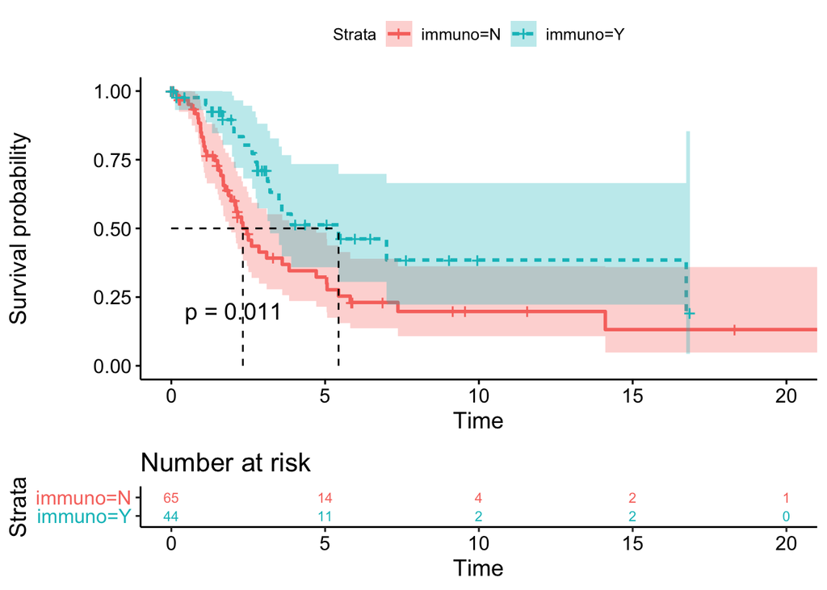

```r
ggsurvplot(fit_stage34_pt,
          pval = TRUE, conf.int = TRUE,
          risk.table = TRUE, # Add risk table
          risk.table.col = "strata", # Change risk table color by groups
          linetype = "strata", # Change line type by groups
          surv.median.line = "hv", # Specify median survival
          fontsize = 3,
          surv.plot.height = 2
          )
```

```r
res.cox <- coxph(Surv(yrs_post_dx, status) ~ immuno, data =  stage34_pt)
summary(res.cox)
```

```
## Call:
## coxph(formula = Surv(yrs_post_dx, status) ~ immuno, data = stage34_pt)
##
##   n= 109, number of events= 60
##    (3 observations deleted due to missingness)
##
##            coef exp(coef) se(coef)      z Pr(>|z|)
## immunoY -0.6995    0.4968   0.2826 -2.475   0.0133 *
## ---
## Signif. codes:  0 '***' 0.001 '**' 0.01 '*' 0.05 '.' 0.1 ' ' 1
##
##         exp(coef) exp(-coef) lower .95 upper .95
## immunoY    0.4968      2.013    0.2855    0.8645
##
## Concordance= 0.606  (se = 0.031 )
## Likelihood ratio test= 6.61  on 1 df,   p=0.01
## Wald test            = 6.13  on 1 df,   p=0.01
## Score (logrank) test = 6.38  on 1 df,   p=0.01
```

**After subsetting the patients in stage 3 or 4, we still see that immunotherapy is protective of patient survival.**